# DEFINING THE QUESTION

Kira Plastinina is a Russian brand that is sold through a defunct chain of retail stores in Russia, Ukraine, Kazakhstan, Belarus, China, Philippines, and Armenia.

The brand’s Sales and Marketing team would like to understand their customer’s behavior from data that they have collected over the past year. More specifically, they would like to learn the characteristics of customer groups.

This Markdown which consists of the following sections

Problem Definition Data Sourcing Check the Data Perform Data Cleaning Perform Exploratory Data Analysis (Univariate, Bivariate & Multivariate) Implement the Solution Challenge the Solution Follow up Questions

The dataset url -[http://bit.ly/EcommerceCustomersDataset]

The dataset consists of 10 numerical and 8 categorical attributes. The ‘Revenue’ attribute can be used as the class label

“Administrative”, “Administrative Duration”, “Informational”, “Informational Duration”, “Product Related” and “Product Related Duration” represents the number of different types of pages visited by the visitor in that session and total time spent in each of these page categories. The values of these features are derived from the URL information of the pages visited by the user and updated in real-time when a user takes an action, e.g. moving from one page to another

The “Bounce Rate”, “Exit Rate” and “Page Value” features represent the metrics measured by “Google Analytics” for each page in the e-commerce site

The value of the “Bounce Rate” feature for a web page refers to the percentage of visitors who enter the site from that page and then leave (“bounce”) without triggering any other requests to the analytics server during that session

The value of the “Exit Rate” feature for a specific web page is calculated as for all pageviews to the page, the percentage that was the last in the session

The “Page Value” feature represents the average value for a web page that a user visited before completing an e-commerce transaction

The “Special Day” feature indicates the closeness of the site visiting time to a specific special day (e.g. Mother’s Day, Valentine’s Day) in which the sessions are more likely to be finalized with the transaction The value of this attribute is determined by considering the dynamics of e-commerce such as the duration between the order date and delivery date. For example, for Valentine’s day, this value takes a nonzero value between February 2 and February 12, zero before and after this date unless it is close to another special day, and its maximum value of 1 on February 8

## The dataset also includes the operating system, browser, region, traffic type, visitor type as returning or new visitor, a Boolean value indicating whether the date of the visit is weekend, and month of the year.

# METRICS OF SUCCESS

### 1.Perform clustering stating insights drawn from your analysis and visualizations.

# EXPERIMENTAL DESIGN

The Markdown contains the following following sections.

- Problem Statement

#### 2.Data Sourcing

#### 3.Check the Data

#### 4.Perform Data Cleaning

#### 5.Perform Exploratory Data Analysis (Univariate, Bivariate & Multivariate)

#### 6.Implement the Solution

#### 7.Challenge the Solution

#### 8.Follow up Questions

1. READING THE DATASET

```r
#install.packages("R6")
```

```r
local({r <- getOption("repos"); r["CRAN"] <- "https://cran.r-project.org/"; options(repos = r)})
```

```r
# Loading the libraries

#library(data.table)
#library(tidyverse)
```

```r
# Reading the data

ecommerce <- read.csv("http://bit.ly/EcommerceCustomersDataset")
```

```r
##Previewing the first 5 rows

head(ecommerce)
```

```
##   Administrative Administrative_Duration Informational Informational_Duration
## 1              0                       0             0                      0
## 2              0                       0             0                      0
## 3              0                      -1             0                     -1
## 4              0                       0             0                      0
## 5              0                       0             0                      0
## 6              0                       0             0                      0
##   ProductRelated ProductRelated_Duration BounceRates ExitRates PageValues
## 1              1                0.000000  0.20000000 0.2000000          0
## 2              2               64.000000  0.00000000 0.1000000          0
## 3              1               -1.000000  0.20000000 0.2000000          0
## 4              2                2.666667  0.05000000 0.1400000          0
## 5             10              627.500000  0.02000000 0.0500000          0
## 6             19              154.216667  0.01578947 0.0245614          0
##   SpecialDay Month OperatingSystems Browser Region TrafficType
## 1          0   Feb                1       1      1           1
## 2          0   Feb                2       2      1           2
## 3          0   Feb                4       1      9           3
## 4          0   Feb                3       2      2           4
## 5          0   Feb                3       3      1           4
## 6          0   Feb                2       2      1           3
##         VisitorType Weekend Revenue
## 1 Returning_Visitor   FALSE   FALSE
## 2 Returning_Visitor   FALSE   FALSE
## 3 Returning_Visitor   FALSE   FALSE
## 4 Returning_Visitor   FALSE   FALSE
## 5 Returning_Visitor    TRUE   FALSE
## 6 Returning_Visitor   FALSE   FALSE
```

```r
##Previewing the last 5 rows

tail(ecommerce)
```

```
##       Administrative Administrative_Duration Informational
## 12325              0                       0             1
## 12326              3                     145             0
## 12327              0                       0             0
## 12328              0                       0             0
## 12329              4                      75             0
## 12330              0                       0             0
##       Informational_Duration ProductRelated ProductRelated_Duration BounceRates
## 12325                      0             16                 503.000 0.000000000
## 12326                      0             53                1783.792 0.007142857
## 12327                      0              5                 465.750 0.000000000
## 12328                      0              6                 184.250 0.083333333
## 12329                      0             15                 346.000 0.000000000
## 12330                      0              3                  21.250 0.000000000
##        ExitRates PageValues SpecialDay Month OperatingSystems Browser Region
## 12325 0.03764706    0.00000          0   Nov                2       2      1
## 12326 0.02903061   12.24172          0   Dec                4       6      1
## 12327 0.02133333    0.00000          0   Nov                3       2      1
## 12328 0.08666667    0.00000          0   Nov                3       2      1
## 12329 0.02105263    0.00000          0   Nov                2       2      3
## 12330 0.06666667    0.00000          0   Nov                3       2      1
##       TrafficType       VisitorType Weekend Revenue
## 12325           1 Returning_Visitor   FALSE   FALSE
## 12326           1 Returning_Visitor    TRUE   FALSE
## 12327           8 Returning_Visitor    TRUE   FALSE
## 12328          13 Returning_Visitor    TRUE   FALSE
## 12329          11 Returning_Visitor   FALSE   FALSE
## 12330           2       New_Visitor    TRUE   FALSE
```

2. EXPLORING THE DATASET

```r
##Viewing the dataset
View(ecommerce)
```

```r
##Checking the shape of the dataset

dim(ecommerce)
```

```
## [1] 12330    18
```

The dataset has 12330 rows and 18 columns

```r
##Checking information of the dataset

str(ecommerce)
```

```
## 'data.frame':    12330 obs. of  18 variables:
##  $ Administrative         : int  0 0 0 0 0 0 0 1 0 0 ...
##  $ Administrative_Duration: num  0 0 -1 0 0 0 -1 -1 0 0 ...
##  $ Informational          : int  0 0 0 0 0 0 0 0 0 0 ...
##  $ Informational_Duration : num  0 0 -1 0 0 0 -1 -1 0 0 ...
##  $ ProductRelated         : int  1 2 1 2 10 19 1 1 2 3 ...
##  $ ProductRelated_Duration: num  0 64 -1 2.67 627.5 ...
##  $ BounceRates            : num  0.2 0 0.2 0.05 0.02 ...
##  $ ExitRates              : num  0.2 0.1 0.2 0.14 0.05 ...
##  $ PageValues             : num  0 0 0 0 0 0 0 0 0 0 ...
##  $ SpecialDay             : num  0 0 0 0 0 0 0.4 0 0.8 0.4 ...
##  $ Month                  : chr  "Feb" "Feb" "Feb" "Feb" ...
##  $ OperatingSystems       : int  1 2 4 3 3 2 2 1 2 2 ...
##  $ Browser                : int  1 2 1 2 3 2 4 2 2 4 ...
##  $ Region                 : int  1 1 9 2 1 1 3 1 2 1 ...
##  $ TrafficType            : int  1 2 3 4 4 3 3 5 3 2 ...
##  $ VisitorType            : chr  "Returning_Visitor" "Returning_Visitor" "Returning_Visitor" "Returning_Visitor" ...
##  $ Weekend                : logi  FALSE FALSE FALSE FALSE TRUE FALSE ...
##  $ Revenue                : logi  FALSE FALSE FALSE FALSE FALSE FALSE ...
```

```r
##checking the column names of the dataset

colnames(ecommerce)
```

```
##  [1] "Administrative"          "Administrative_Duration"
##  [3] "Informational"           "Informational_Duration"
##  [5] "ProductRelated"          "ProductRelated_Duration"
##  [7] "BounceRates"             "ExitRates"
##  [9] "PageValues"              "SpecialDay"
## [11] "Month"                   "OperatingSystems"
## [13] "Browser"                 "Region"
## [15] "TrafficType"             "VisitorType"
## [17] "Weekend"                 "Revenue"
```

```r
##Checking the datatypes of the dataset

class(ecommerce)
```

```
## [1] "data.frame"
```

```r
sapply(ecommerce,class)
```

```
##          Administrative Administrative_Duration           Informational
##               "integer"               "numeric"               "integer"
##  Informational_Duration          ProductRelated ProductRelated_Duration
##               "numeric"               "integer"               "numeric"
##             BounceRates               ExitRates              PageValues
##               "numeric"               "numeric"               "numeric"
##              SpecialDay                   Month        OperatingSystems
##               "numeric"             "character"               "integer"
##                 Browser                  Region             TrafficType
##               "integer"               "integer"               "integer"
##             VisitorType                 Weekend                 Revenue
##             "character"               "logical"               "logical"
```

```r
##Important features

df <- ecommerce[, c(1,2,3,4,5,6,7,8,9,10)]
names(df)
```

```
##  [1] "Administrative"          "Administrative_Duration"
##  [3] "Informational"           "Informational_Duration"
##  [5] "ProductRelated"          "ProductRelated_Duration"
##  [7] "BounceRates"             "ExitRates"
##  [9] "PageValues"              "SpecialDay"
```

3. DATA CLEANING

```r
##Checking for missing values

sum(is.na(df))
```

```
## [1] 112
```

```r
##Dealing with missing values

ecomm<-na.omit(df)
sum(is.na(df))
```

```
## [1] 112
```

```r
##Checking for duplicates

sum(duplicated(df))
```

```
## [1] 764
```

```r
##Dealing with duplicates
###To deal with duplicates i pick the non duplicated data

df = ecomm[!duplicated(df), ]
dim(df)
```

```
## [1] 11566    10
```

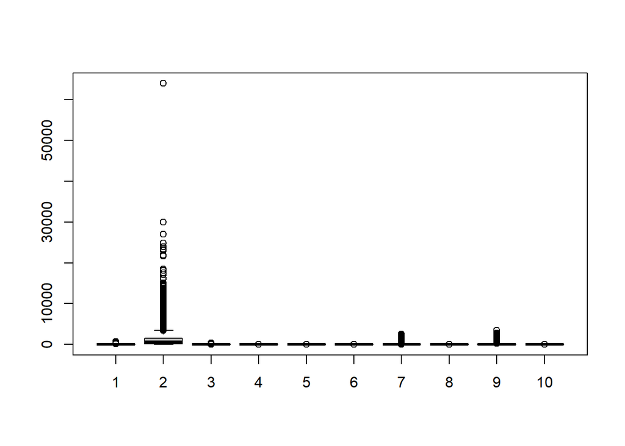

```r
##Checking for outliers

product_related<-df$ProductRelated
product_related_duration<-df$ProductRelated_Duration
page_values<-df$PageValues
Administrative<-df$Administrative
Administrative_Duration<-df$Administrative_Duration
Informational<-df$Informational
Informational_Duration<-df$Informational_Duration
BounceRates<-df$BounceRates
ExitRates<-df$ExitRates
SpecialDay<-df$SpecialDay
boxplot(product_related,product_related_duration,page_values,SpecialDay,ExitRates,BounceRates,Informational_Duration,Informational,Administrative_Duration,Administrative)
```

4. EDA

4.1 Univariate Analysis

```r
#Summary of the descriptive statistics

summary(df)
```

```
##  Administrative   Administrative_Duration Informational
##  Min.   : 0.000   Min.   :  -1.00         Min.   : 0.0000
##  1st Qu.: 0.000   1st Qu.:   0.00         1st Qu.: 0.0000
##  Median : 1.000   Median :   9.00         Median : 0.0000
##  Mean   : 2.329   Mean   :  80.69         Mean   : 0.5066
##  3rd Qu.: 4.000   3rd Qu.:  93.90         3rd Qu.: 0.0000
##  Max.   :27.000   Max.   :3398.75         Max.   :16.0000
##  NA's   :13       NA's   :13              NA's   :13
##  Informational_Duration ProductRelated   ProductRelated_Duration
##  Min.   :  -1.0         Min.   :  0.00   Min.   :   -1.0
##  1st Qu.:   0.0         1st Qu.:  8.00   1st Qu.:  191.0
##  Median :   0.0         Median : 18.00   Median :  603.7
##  Mean   :  34.8         Mean   : 31.82   Mean   : 1196.0
##  3rd Qu.:   0.0         3rd Qu.: 38.00   3rd Qu.: 1471.9
##  Max.   :2549.4         Max.   :686.00   Max.   :63973.5
##  NA's   :13             NA's   :13       NA's   :13
##   BounceRates         ExitRates         PageValues        SpecialDay
##  Min.   :0.000000   Min.   :0.00000   Min.   :  0.000   Min.   :0.00000
##  1st Qu.:0.000000   1st Qu.:0.01422   1st Qu.:  0.000   1st Qu.:0.00000
##  Median :0.002989   Median :0.02500   Median :  0.000   Median :0.00000
##  Mean   :0.020887   Mean   :0.04184   Mean   :  5.939   Mean   :0.06146
##  3rd Qu.:0.016667   3rd Qu.:0.04956   3rd Qu.:  0.000   3rd Qu.:0.00000
##  Max.   :0.200000   Max.   :0.20000   Max.   :361.764   Max.   :1.00000
##  NA's   :13         NA's   :13        NA's   :13        NA's   :13
```

```r
#Plotting Histogram of selected features

# install.packages("DataExplorer")

#library(DataExplorer)
# plot_histogram(df)
```

```r
#creating bar plots for all categorical columns
month_table <- table(ecommerce$Month)
```

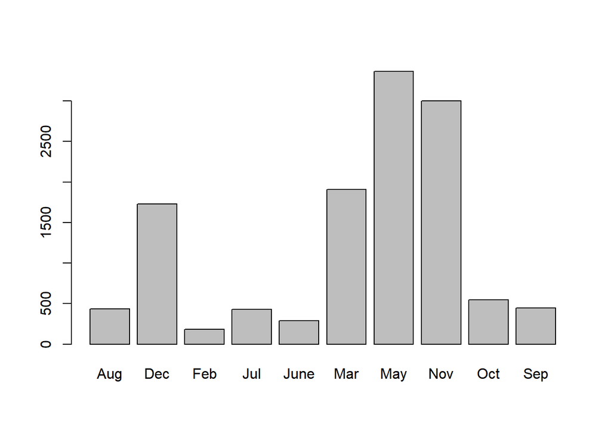

```r
#creating barplot for month

barplot(month_table)
```

```r
##the month of May had the most visits to the site while February was the least visited
```

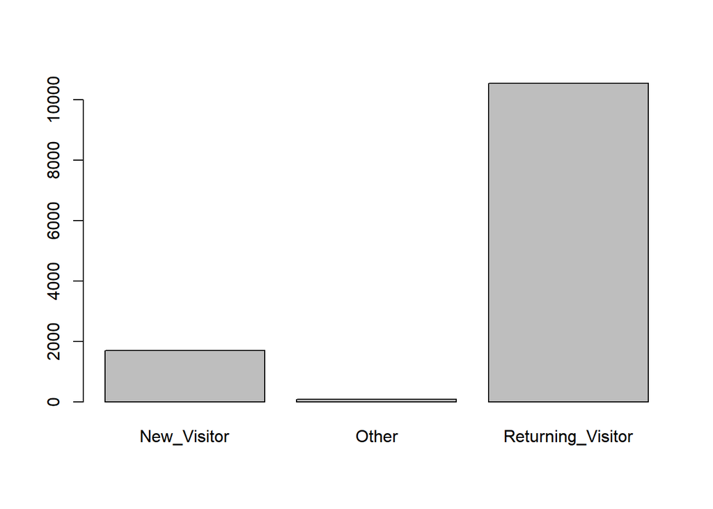

```r
#Barplot indicating visitor type

visitor_table <- table(ecommerce$VisitorType)
barplot(visitor_table)
```

Returning visitors form the majority of of the visitor type

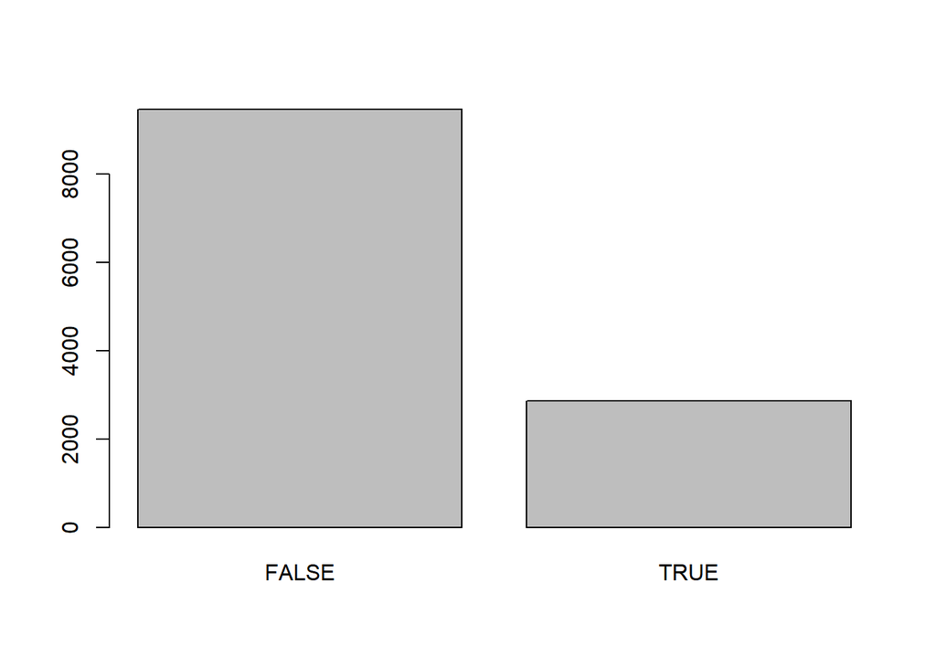

```r
#Weekend barplot

weekend_table <- table(ecommerce$Weekend)
barplot(weekend_table)
```

The site receives more visitors during the weekdays

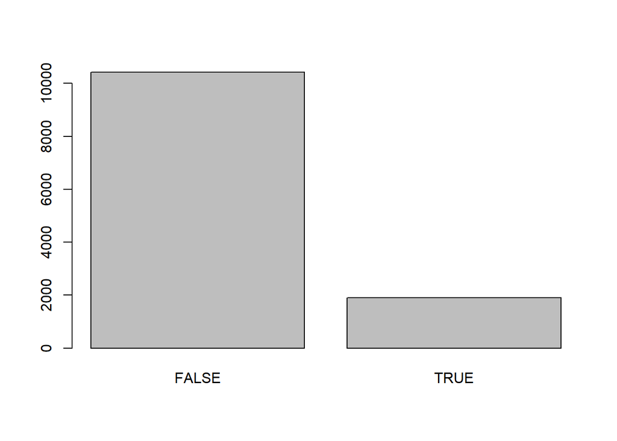

```r
#Revenue barplot

revenue_table <- table(ecommerce$Revenue)
barplot(revenue_table)
```

- Individuals who visit the site and generate revenue are less
- Majority of the people visit the site but the visits don’t directly generate any revenue

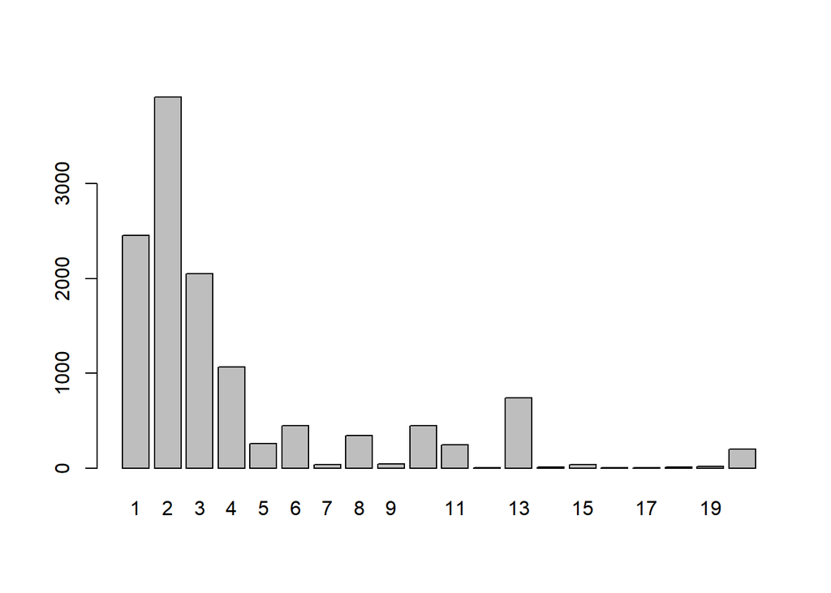

```r
#Barplot on traffic type

traffic_table <- table(ecommerce$TrafficType)
barplot(traffic_table)
```

Type 2 traffic is the highest followed by Type 1 traffic

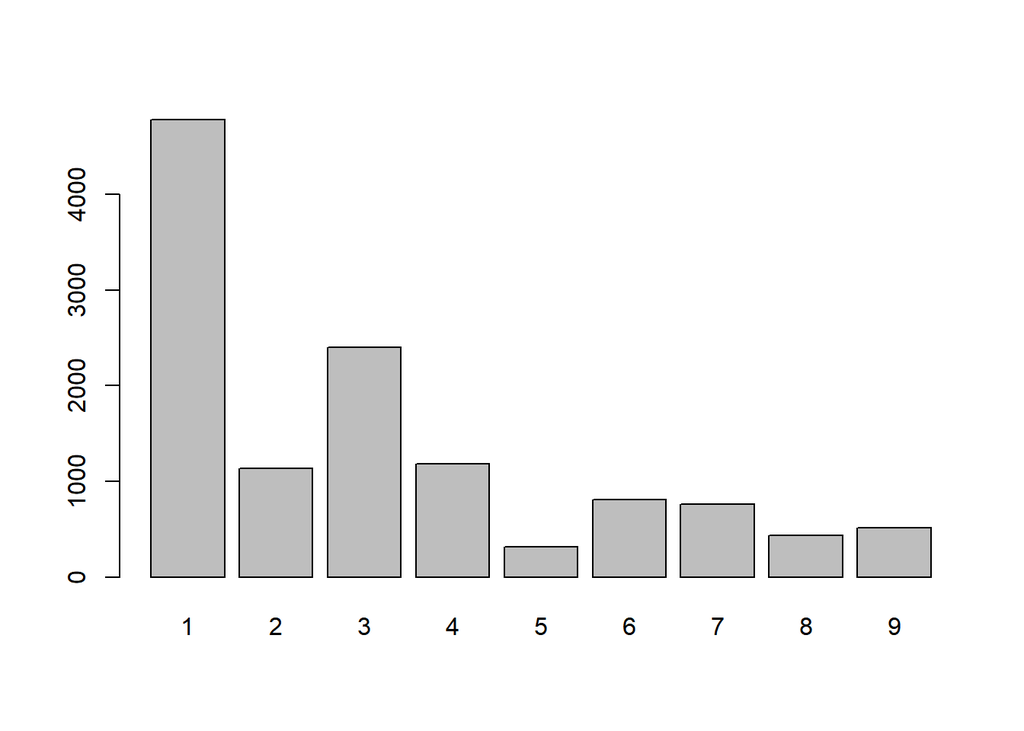

```r
# Region Barplot

region_table <- table(ecommerce$Region)
barplot(region_table)
```

Region 1 has the majority of people who visit the site while region 5 has the lowest number of visitors

BIVARIATE

```r
##correlation

page_values<-ecomm$PageValues
product_related<-ecomm$ProductRelated
cor(page_values,product_related)
```

```
## [1] 0.05606696
```

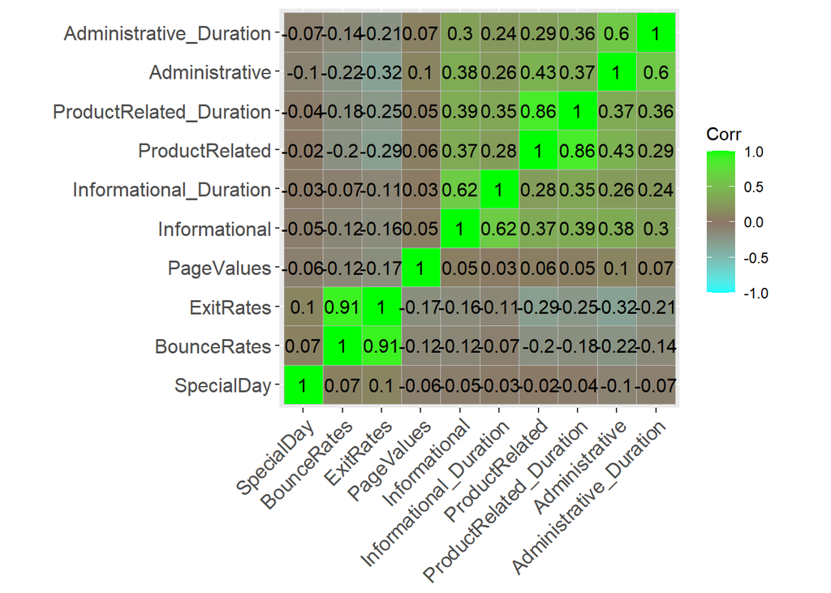

```r
#correlation plot

library(ggcorrplot)
library(dplyr)
corr = round(cor(select_if(ecomm, is.numeric)), 4)
ggcorrplot(corr, hc.order = T, ggtheme = ggplot2::theme_grey,
   colors = c("cyan", "peachpuff4", "green"), lab = T)
```

There is a high correlation between the bounce rate and the exit rate

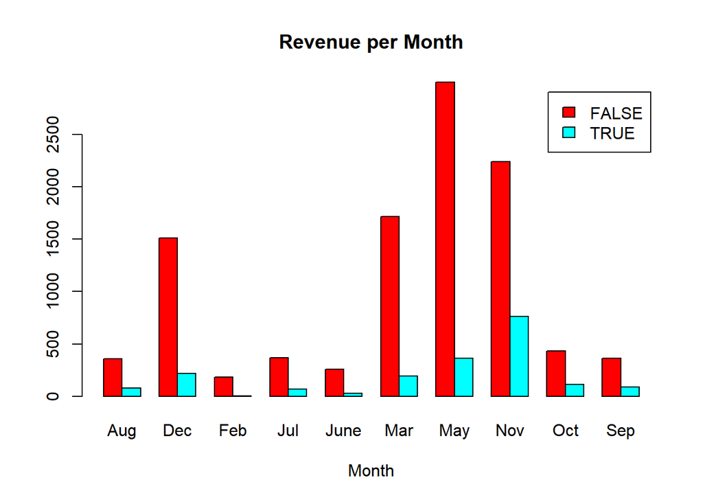

```r
##plotting revenue per month

rev_month <- table(ecommerce$Revenue, ecommerce$Month)
barplot(rev_month, main = "Revenue per Month", col = c("red", "cyan"), beside = TRUE,
        legend = rownames(rev_month), xlab = "Month")
```

November has the highest revenue. This could be explained by huge end of year sales such as Black Friday all month long

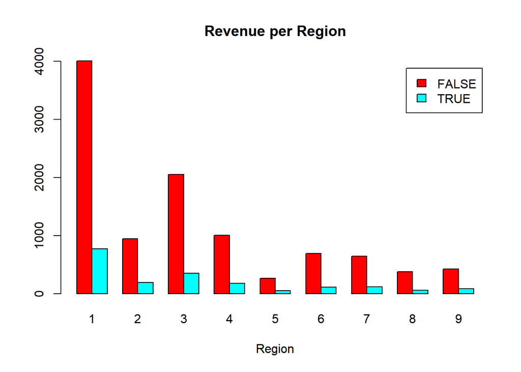

```r
##plotting revenue per region

rev_region <- table(ecommerce$Revenue, ecommerce$Region)
barplot(rev_region, main = "Revenue per Region", col = c("red", "cyan"), beside = TRUE,
        legend = rownames(rev_region), xlab = "Region")
```

Region 1 returned the highest revenue while region 5 returned the lowest

```r
head(ecommerce)
```

```
##   Administrative Administrative_Duration Informational Informational_Duration
## 1              0                       0             0                      0
## 2              0                       0             0                      0
## 3              0                      -1             0                     -1
## 4              0                       0             0                      0
## 5              0                       0             0                      0
## 6              0                       0             0                      0
##   ProductRelated ProductRelated_Duration BounceRates ExitRates PageValues
## 1              1                0.000000  0.20000000 0.2000000          0
## 2              2               64.000000  0.00000000 0.1000000          0
## 3              1               -1.000000  0.20000000 0.2000000          0
## 4              2                2.666667  0.05000000 0.1400000          0
## 5             10              627.500000  0.02000000 0.0500000          0
## 6             19              154.216667  0.01578947 0.0245614          0
##   SpecialDay Month OperatingSystems Browser Region TrafficType
## 1          0   Feb                1       1      1           1
## 2          0   Feb                2       2      1           2
## 3          0   Feb                4       1      9           3
## 4          0   Feb                3       2      2           4
## 5          0   Feb                3       3      1           4
## 6          0   Feb                2       2      1           3
##         VisitorType Weekend Revenue
## 1 Returning_Visitor   FALSE   FALSE
## 2 Returning_Visitor   FALSE   FALSE
## 3 Returning_Visitor   FALSE   FALSE
## 4 Returning_Visitor   FALSE   FALSE
## 5 Returning_Visitor    TRUE   FALSE
## 6 Returning_Visitor   FALSE   FALSE
```

```r
df <- ecommerce
```

5. IMPLEMENTING THE SOLUTION

## K-MEANS CLUSTERING

#### Normalizing the required features

```r
normalize <- function(x){
  return ((x-min(x)) / (max(x)-min(x)))
}
df$ProductRelated<- normalize(df$ProductRelated)
df$ProductRelated_Duration<- normalize(df$ProductRelated_Duration)
df$PageValues<- normalize(df$PageValues)
head(df)
```

```
##   Administrative Administrative_Duration Informational Informational_Duration
## 1              0                       0             0                      0
## 2              0                       0             0                      0
## 3              0                      -1             0                     -1
## 4              0                       0             0                      0
## 5              0                       0             0                      0
## 6              0                       0             0                      0
##   ProductRelated ProductRelated_Duration BounceRates ExitRates PageValues
## 1             NA                      NA  0.20000000 0.2000000          0
## 2             NA                      NA  0.00000000 0.1000000          0
## 3             NA                      NA  0.20000000 0.2000000          0
## 4             NA                      NA  0.05000000 0.1400000          0
## 5             NA                      NA  0.02000000 0.0500000          0
## 6             NA                      NA  0.01578947 0.0245614          0
##   SpecialDay Month OperatingSystems Browser Region TrafficType
## 1          0   Feb                1       1      1           1
## 2          0   Feb                2       2      1           2
## 3          0   Feb                4       1      9           3
## 4          0   Feb                3       2      2           4
## 5          0   Feb                3       3      1           4
## 6          0   Feb                2       2      1           3
##         VisitorType Weekend Revenue
## 1 Returning_Visitor   FALSE   FALSE
## 2 Returning_Visitor   FALSE   FALSE
## 3 Returning_Visitor   FALSE   FALSE
## 4 Returning_Visitor   FALSE   FALSE
## 5 Returning_Visitor    TRUE   FALSE
## 6 Returning_Visitor   FALSE   FALSE
```

```r
####selecting necesarry columns
df1<-ecommerce[c(5,6,9)]
colnames(df1)
```

```
## [1] "ProductRelated"          "ProductRelated_Duration"
## [3] "PageValues"
```

```r
head(df1)
```

```
##   ProductRelated ProductRelated_Duration PageValues
## 1              1                0.000000          0
## 2              2               64.000000          0
## 3              1               -1.000000          0
## 4              2                2.666667          0
## 5             10              627.500000          0
## 6             19              154.216667          0
```

```r
df1
```

[output not shown]

[output cut: 12316 more lines]

```r
sum(is.na(df1))
```

```
## [1] 28
```

```r
df2 <- na.omit(df1)
```

```r
sum(is.na(df2))
```

```
## [1] 0
```

```r
#
# Applying the K-means clustering algorithm with number of centroids(k)=3
result<- kmeans(df2,3)

# Previewing the no. of records in each cluster
result$size
```

```
## [1] 10133   207  1976
```

```r
#value of cluster center datapoint
result$centers
```

```
##   ProductRelated ProductRelated_Duration PageValues
## 1       18.62311                577.1859   5.512310
## 2      236.10628              10886.1744   4.521370
## 3       77.74393               3354.4179   8.007283
```

```r
#cluster vector showing each record
result$cluster
```

[output not shown]

[output cut: 1881 more lines]

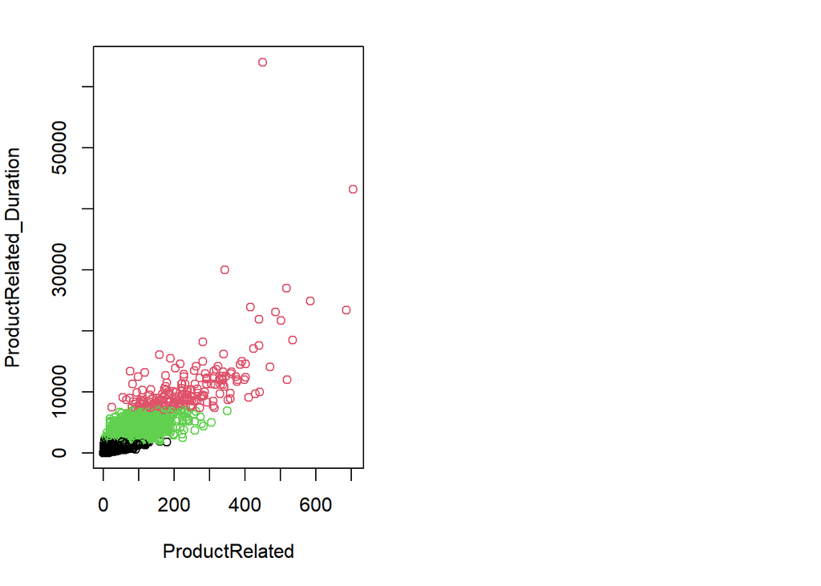

```r
# Visualizing the clustering results
par(mfrow = c(1,2), mar = c(5,4,2,2))

#plotting to see how product related duration and product related have been distributed
plot(df2[,1:2], col = result$cluster)
```

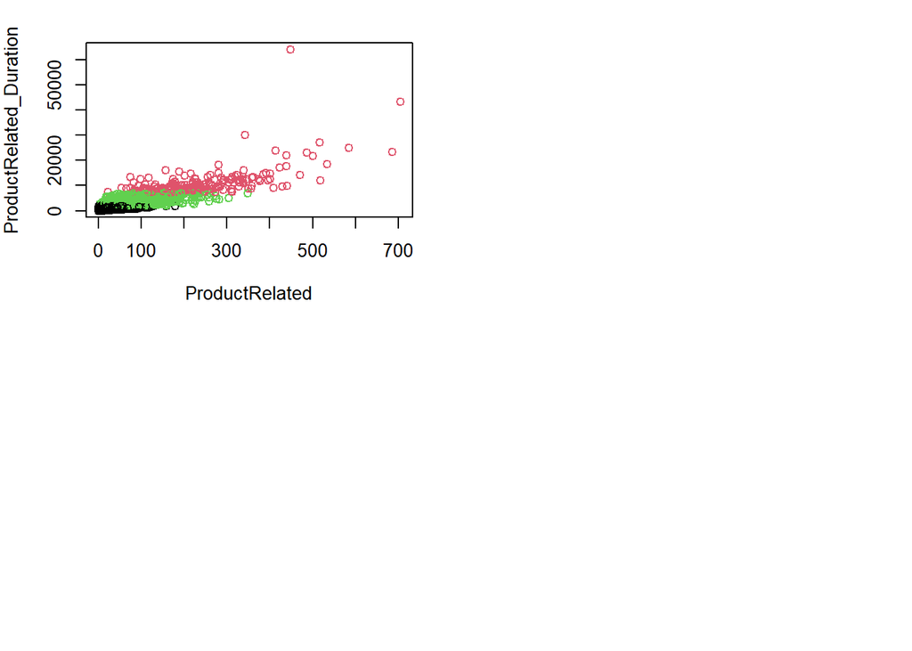

```r
#Verifying the results of clustering
par(mfrow = c(2,2), mar = c(5,4,2,2))

#Plotting product related duration and product related
plot(df2[c(1,2)], col = result$cluster)
```

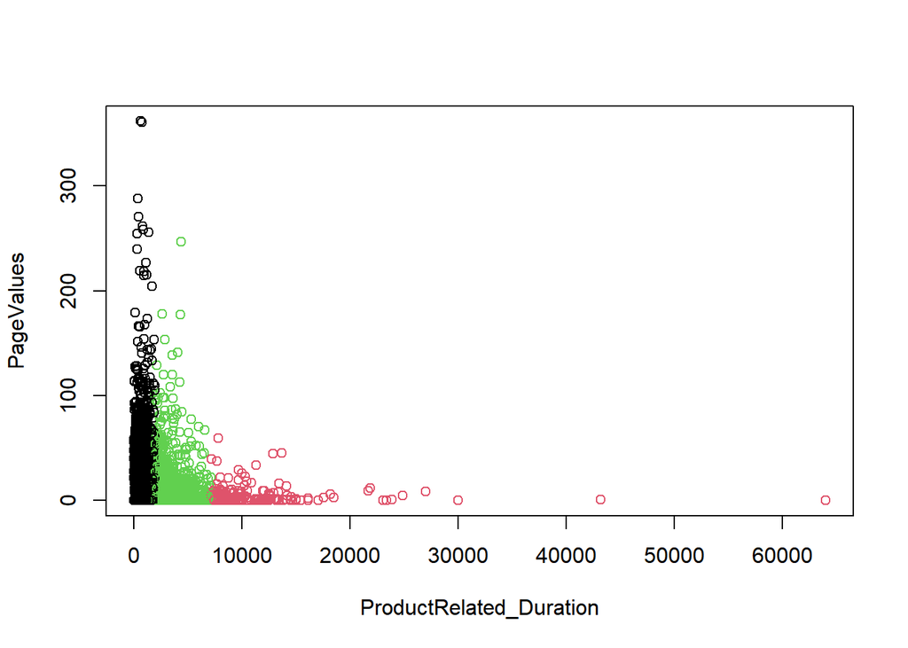

```r
#plotting page values and product related duration to check the distribution
plot(df2[c(2,3)], col = result$cluster)
```

```r
#Implementing with class attribute 'revenue'

df2.class<- ecommerce[, "Revenue"]
```

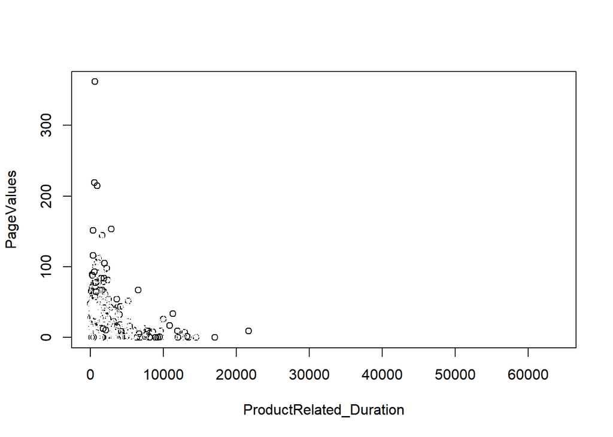

```r
plot(df2[c(2,3)], col = df2.class)
```

HIERARCHICAL CLUSTERING

```r
# Scaling the data

df2<-scale(df2)
head(df2)
```

```
##   ProductRelated ProductRelated_Duration PageValues
## 1     -0.6914734              -0.6247671 -0.3173633
## 2     -0.6689966              -0.5913358 -0.3173633
## 3     -0.6914734              -0.6252895 -0.3173633
## 4     -0.6689966              -0.6233742 -0.3173633
## 5     -0.4891823              -0.2969835 -0.3173633
## 6     -0.2868911              -0.5442099 -0.3173633
```

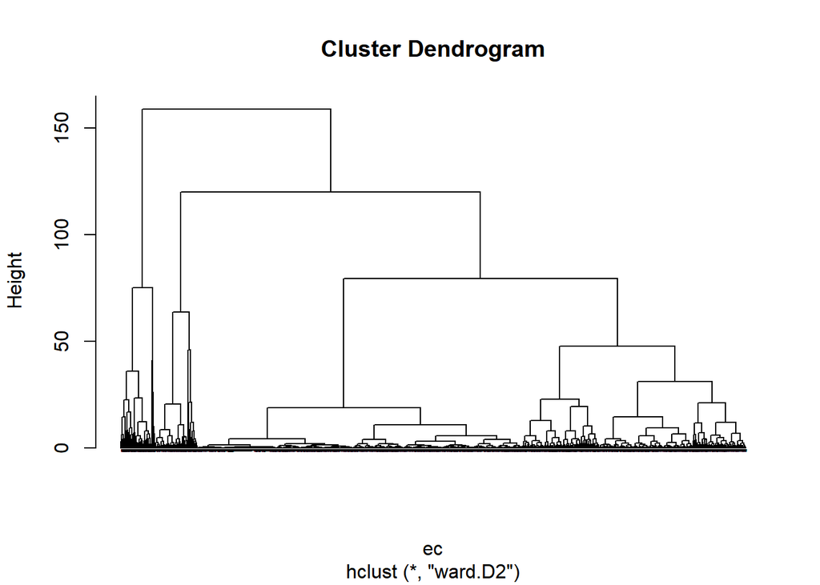

```r
#computing the euclidean distance
ec<-dist(df2,method = "euclidean")


#performing hierarchical clustering
HC<-hclust(ec,method = "ward.D2")


#plotting the dendrogram
plot(HC,cex=0.001,hang= -1)
```

- No conclusionsfrom the dendogram